# Bird Data

Tim Dennis

7/21/2019

## Extracted Bird Data

A researcher came with bird observation data for Los Angeles California from 1950 to 2019. We tried to open in a text editor but it crashed b/c it was too big (2.1 GB). From here, we switched to the command line to inspect the file. First step is to see how many lines:

```bash
wc -l ebd_US-CA-037_195001_201902_relJan-2019.txt
```

```
##  5673017 ebd_US-CA-037_195001_201902_relJan-2019.txt
```

Ok 5 million lines, for older MACs or PCs that are running a bunch of stuff, this will make that machien crawl. At this point you could close everything to free up memory, but let’s inspect a bit more inside the file. How do we do this if we can’t open it? Ah, UNIX is your friend.

Let’s use head to look at the top of the file:

```bash
head ebd_US-CA-037_195001_201902_relJan-2019.txt
```

```
## GLOBAL UNIQUE IDENTIFIER LAST EDITED DATE    TAXONOMIC ORDER CATEGORY    COMMON NAME SCIENTIFIC NAME SUBSPECIES COMMON NAME  SUBSPECIES SCIENTIFIC NAME  OBSERVATION COUNT   BREEDING BIRD ATLAS CODE    BREEDING BIRD ATLAS CATEGORY    AGE/SEX COUNTRY COUNTRY CODE    STATE   STATE CODE  COUNTY  COUN…
## URN:CornellLabOfOrnithology:EBIRD:OBS173045506   2013-09-30 11:26:37.0   29595   species American Pipit  Anthus rubescens            X               United States   US  California  US-CA   Los Angeles US-CA-037                   Playa del Rey   L1649065    P   33.9498679  -118.4751858    1950-01-…
## URN:CornellLabOfOrnithology:EBIRD:OBS160822763   2013-09-30 11:26:37.0   438 species American Wigeon Mareca americana            X               United States   US  California  US-CA   Los Angeles US-CA-037                   Playa del Rey   L1649065    P   33.9498679  -118.4751858    1950-01-06  …
## URN:CornellLabOfOrnithology:EBIRD:OBS161316381   2013-09-30 11:26:37.0   5576    species Black-bellied Plover    Pluvialis squatarola            X               United States   US  California  US-CA   Los Angeles US-CA-037                   Playa del Rey   L1649065    P   33.9498679  -118.4751858…
## URN:CornellLabOfOrnithology:EBIRD:OBS160401626   2012-08-07 17:42:36.0   6570    species Black-footed Albatross  Phoebastria nigripes            X               United States   US  California  US-CA   Los Angeles US-CA-037                   Offshore--Santa Catalina Island vicinity (LA Co.)   L970…
## URN:CornellLabOfOrnithology:EBIRD:OBS161123733   2013-09-30 11:26:37.0   5572    species Black Oystercatcher Haematopus bachmani         X               United States   US  California  US-CA   Los Angeles US-CA-037                   Playa del Rey   L1649065    P   33.9498679  -118.4751858    1950…
## URN:CornellLabOfOrnithology:EBIRD:OBS160851239   2013-09-30 11:26:37.0   624 species Black Scoter    Melanitta americana         X               United States   US  California  US-CA   Los Angeles US-CA-037                   Playa del Rey   L1649065    P   33.9498679  -118.4751858    1950-01-06  …
## URN:CornellLabOfOrnithology:EBIRD:OBS178199585   2016-05-29 17:40:06.0   5798    species Black Turnstone Arenaria melanocephala          X               United States   US  California  US-CA   Los Angeles US-CA-037   US-CA_3083  32          Ballona Creek--Creek mouth, jetties and breakwater  L247…
## URN:CornellLabOfOrnithology:EBIRD:OBS161601125   2013-09-30 11:26:37.0   6171    species Bonaparte's Gull    Chroicocephalus philadelphia            X               United States   US  California  US-CA   Los Angeles US-CA-037                   Playa del Rey   L1649065    P   33.9498679  -118.475…
## URN:CornellLabOfOrnithology:EBIRD:OBS160469561   2012-08-08 16:50:01.0   6908    species Brandt's Cormorant  Phalacrocorax penicillatus          X               United States   US  California  US-CA   Los Angeles US-CA-037                   Offshore--Santa Catalina Island vicinity (LA Co.)   L970…
```

Ok, promising, we have bird data! The first header contains the column names or variables. We can use head to pull out just that first row.

```bash
head -n 1 ebd_US-CA-037_195001_201902_relJan-2019.txt
```

```
## GLOBAL UNIQUE IDENTIFIER LAST EDITED DATE    TAXONOMIC ORDER CATEGORY    COMMON NAME SCIENTIFIC NAME SUBSPECIES COMMON NAME  SUBSPECIES SCIENTIFIC NAME  OBSERVATION COUNT   BREEDING BIRD ATLAS CODE    BREEDING BIRD ATLAS CATEGORY    AGE/SEX COUNTRY COUNTRY CODE    STATE   STATE CODE  COUNTY  COUN…
```

Just from looking at the data this way we can see that it’s tab delimited. We also can see we probably don’t need all these columns. Let’s use the command `cut` to reduce the number of columns in the dataset. For this demo I’m cutting some stuff I probably wouldn’t. I hate counting like that so let’s output with some line numbers and transpose our column names. I’m using a command called datamash https://www.gnu.org/software/datamash/examples/.

```bash
head -1 ebd_US-CA-037_195001_201902_relJan-2019.txt | datamash transpose | cat -n
```

```
##      1   GLOBAL UNIQUE IDENTIFIER
##      2   LAST EDITED DATE
##      3   TAXONOMIC ORDER
##      4   CATEGORY
##      5   COMMON NAME
##      6   SCIENTIFIC NAME
##      7   SUBSPECIES COMMON NAME
##      8   SUBSPECIES SCIENTIFIC NAME
##      9   OBSERVATION COUNT
##     10   BREEDING BIRD ATLAS CODE
##     11   BREEDING BIRD ATLAS CATEGORY
##     12   AGE/SEX
##     13   COUNTRY
##     14   COUNTRY CODE
##     15   STATE
```

[output cut: 32 more lines]

Now we can cut which cuts out columns for retention:

```bash
head -10 ebd_US-CA-037_195001_201902_relJan-2019.txt | cut -f5,17,26,27,28
```

```
## COMMON NAME  COUNTY  LATITUDE    LONGITUDE   OBSERVATION DATE
## American Pipit   Los Angeles 33.9498679  -118.4751858    1950-01-06
## American Wigeon  Los Angeles 33.9498679  -118.4751858    1950-01-06
## Black-bellied Plover Los Angeles 33.9498679  -118.4751858    1950-01-06
## Black-footed Albatross   Los Angeles 33.254074   -118.504167 1950-01-07
## Black Oystercatcher  Los Angeles 33.9498679  -118.4751858    1950-01-06
## Black Scoter Los Angeles 33.9498679  -118.4751858    1950-01-06
## Black Turnstone  Los Angeles 33.96196    -118.4570897    1950-01-08
## Bonaparte's Gull Los Angeles 33.9498679  -118.4751858    1950-01-06
## Brandt's Cormorant   Los Angeles 33.254074   -118.504167 1950-01-07
```

We can run this on the whole file now and save it for further processing:

```bash
cut -f5,17,26-27,28 ebd_US-CA-037_195001_201902_relJan-2019.txt | wc -c
```

```
##  355732934
```

```bash
cut -f5,17,26-27,28 ebd_US-CA-037_195001_201902_relJan-2019.txt > ebd_la_reduced.tsv
```

```bash
head -1 ebd_la_reduced.tsv | datamash transpose | cat -n
```

```
##      1   COMMON NAME
##      2   COUNTY
##      3   LATITUDE
##      4   LONGITUDE
##      5   OBSERVATION DATE
```

How about we filter out some rows? Our researcher was primarily only interested in data from the 2000s. How would we do this? I’m going to use awk! It’s a tool for data extraction in Unix. I’ll work on only a few lines at first.

```bash
tail -100 ebd_la_reduced.tsv | awk '$7 ~ /^20[0-9]{2}/'
```

```
## Yellow-rumped Warbler    Los Angeles 33.8816124  -118.2623184    2019-01-29
## Yellow-rumped Warbler    Los Angeles 34.0887059  -118.3179045    2019-01-02
## Yellow-rumped Warbler    Los Angeles 33.8816124  -118.2623184    2019-01-01
## Yellow-rumped Warbler    Los Angeles 33.8816124  -118.2623184    2019-01-01
## Yellow-rumped Warbler    Los Angeles 34.1631675  -118.3802819    2019-01-04
## Yellow-rumped Warbler    Los Angeles 34.180796   -118.097705 2019-01-20
## Yellow-rumped Warbler    Los Angeles 33.8816124  -118.2623184    2019-01-01
## Yellow-rumped Warbler    Los Angeles 33.8816124  -118.2623184    2019-01-30
## Yellow-rumped Warbler    Los Angeles 33.8816124  -118.2623184    2019-01-25
## Yellow-rumped Warbler    Los Angeles 33.8816124  -118.2623184    2019-01-01
## Yellow-rumped Warbler    Los Angeles 34.0887059  -118.3179045    2019-01-12
## Yellow-rumped Warbler    Los Angeles 33.715679   -118.317542 2019-01-27
## Yellow-rumped Warbler    Los Angeles 34.6127674  -118.1804724    2019-01-10
## Yellow-rumped Warbler    Los Angeles 34.137561   -118.1677651    2019-01-03
## Yellow-rumped Warbler    Los Angeles 34.140593   -118.365486 2019-01-02
## Yellow-rumped Warbler    Los Angeles 34.140593   -118.365486 2019-01-02
## Yellow-rumped Warbler    Los Angeles 34.4069097  -118.5719633    2019-01-15
## Yellow-rumped Warbler    Los Angeles 34.137561   -118.1677651    2019-01-22
## Yellow-rumped Warbler    Los Angeles 34.137561   -118.1677651    2019-01-13
## Yellow-rumped Warbler    Los Angeles 34.1641606  -118.0063927    2019-01-02
## Yellow-rumped Warbler    Los Angeles 34.137561   -118.1677651    2019-01-16
## Yellow-rumped Warbler    Los Angeles 34.309962   -118.5138345    2019-01-21
## Yellow-rumped Warbler    Los Angeles 34.1641606  -118.0063927    2019-01-11
## Yellow-rumped Warbler    Los Angeles 34.6127674  -118.1804724    2019-01-09
## Yellow-rumped Warbler    Los Angeles 33.7935087  -118.2041102    2019-01-28
## Yellow-rumped Warbler    Los Angeles 34.6127674  -118.1804724    2019-01-10
## Yellow-rumped Warbler    Los Angeles 34.137561   -118.1677651    2019-01-02
## Yellow-rumped Warbler    Los Angeles 34.137561   -118.1677651    2019-01-06
## Yellow-rumped Warbler    Los Angeles 34.137561   -118.1677651    2019-01-05
## Yellow-rumped Warbler    Los Angeles 34.4069097  -118.5719633    2019-01-24
## Yellow-rumped Warbler    Los Angeles 34.140593   -118.365486 2019-01-02
## Yellow-rumped Warbler    Los Angeles 34.137561   -118.1677651    2019-01-10
## Yellow-rumped Warbler    Los Angeles 34.0434143  -118.5316658    2019-01-01
## Yellow-rumped Warbler    Los Angeles 33.9883936  -118.4139544    2019-01-06
## Yellow-rumped Warbler    Los Angeles 34.137561   -118.1677651    2019-01-06
## Yellow-rumped Warbler    Los Angeles 34.1641606  -118.0063927    2019-01-29
## Yellow-rumped Warbler    Los Angeles 34.309962   -118.5138345    2019-01-28
## Yellow-rumped Warbler    Los Angeles 33.7935087  -118.2041102    2019-01-28
## Yellow-rumped Warbler    Los Angeles 34.1641606  -118.0063927    2019-01-03
## Yellow-rumped Warbler    Los Angeles 33.7995405  -118.1655924    2019-01-09
```

[output cut: 45 more lines]

```
## Zone-tailed Hawk Los Angeles 34.1585866  -117.9915333    2019-01-19
## Zone-tailed Hawk Los Angeles 34.1585866  -117.9915333    2019-01-19
## Zone-tailed Hawk Los Angeles 34.1585866  -117.9915333    2019-01-19
## Zone-tailed Hawk Los Angeles 34.1585866  -117.9915333    2019-01-18
## Zone-tailed Hawk Los Angeles 34.1585866  -117.9915333    2019-01-13
## Zone-tailed Hawk Los Angeles 34.1585866  -117.9915333    2019-01-13
## Zone-tailed Hawk Los Angeles 34.1585866  -117.9915333    2019-01-19
## Zone-tailed Hawk Los Angeles 34.1585866  -117.9915333    2019-01-13
## Zone-tailed Hawk Los Angeles 34.1585866  -117.9915333    2019-01-14
## Zone-tailed Hawk Los Angeles 34.1537569  -117.9858685    2019-01-12
## Zone-tailed Hawk Los Angeles 34.1585866  -117.9915333    2019-01-13
## Zone-tailed Hawk Los Angeles 34.1599502  -117.9968417    2019-01-20
## Zone-tailed Hawk Los Angeles 34.159085   -117.979342 2019-01-16
## Zone-tailed Hawk Los Angeles 34.159085   -117.979342 2019-01-16
## Zone-tailed Hawk Los Angeles 34.158946   -117.991366 2019-01-21
```

Ok, now let’s winnow down our data set to just those from the 2000s. We could also use the `shuf` command to randomly sample a number of lines. See this tutorial: https://shapeshed.com/unix-shuf/#how-to-pick-a-random-line-from-a-file

```bash
head -n 1 ebd_la_reduced.tsv > 2000s_bird_la.tsv
awk '$7 ~ /200[0-9]-[0-9]{2}-[0-9]{2}/' ebd_la_reduced.tsv >> 2000s_bird_la.tsv
```

We can look and see what the file is:

```bash
head -20 2000s_bird_la.tsv
```

```
## COMMON NAME  COUNTY  LATITUDE    LONGITUDE   OBSERVATION DATE
## Acorn Woodpecker Los Angeles 34.1722221  -118.1715846    2000-01-02
## Acorn Woodpecker Los Angeles 34.2777158  -118.1131124    2000-01-19
## Acorn Woodpecker Los Angeles 34.1266554  -117.7420342    2000-01-07
## Acorn Woodpecker Los Angeles 34.3534343  -117.9929817    2000-01-13
## Acorn Woodpecker Los Angeles 34.1266554  -117.7420342    2000-01-26
## Acorn Woodpecker Los Angeles 34.1366907  -118.1254292    2000-01-26
## Acorn Woodpecker Los Angeles 34.1366907  -118.1254292    2000-01-03
## Acorn Woodpecker Los Angeles 34.1266554  -117.7420342    2000-01-13
## Acorn Woodpecker Los Angeles 34.1266554  -117.7420342    2000-01-25
## Acorn Woodpecker Los Angeles 34.1266554  -117.7420342    2000-01-01
## Acorn Woodpecker Los Angeles 34.1266554  -117.7420342    2000-01-19
## Acorn Woodpecker Los Angeles 34.1266554  -117.7420342    2000-01-27
## Acorn Woodpecker Los Angeles 34.1266554  -117.7420342    2000-01-21
## Acorn Woodpecker Los Angeles 34.1366907  -118.1254292    2000-01-19
## Acorn Woodpecker Los Angeles 34.1366907  -118.1254292    2000-01-11
## Acorn Woodpecker Los Angeles 34.1266554  -117.7420342    2000-01-04
## Acorn Woodpecker Los Angeles 34.1266554  -117.7420342    2000-01-15
## Acorn Woodpecker Los Angeles 34.1266554  -117.7420342    2000-01-16
## Acorn Woodpecker Los Angeles 34.1266554  -117.7420342    2000-01-02
```

The `ls` file has a `h` flag that when used with the `l` flag will give us the human readable size (so instead of in bytes, shows us gigabites size).

```bash
ls -lh
```

```
## total 5214736
## -rw-r--r--  1 timdennis  staff    34M Jul 25 14:53 2000s_bird_la.tsv
## -rw-r--r--@ 1 timdennis  staff   6.5K Jul 25 14:51 bird.Rmd
## -rw-r--r--  1 timdennis  staff   2.0M Jul 23 09:42 bird.html
## -rw-r--r--@ 1 timdennis  staff   205B Jul 25 14:32 bird_data_ann_youngdahl.Rproj
## -rw-r--r--@ 1 timdennis  staff   2.1G Apr 23 15:57 ebd_US-CA-037_195001_201902_relJan-2019.txt
## -rw-r--r--  1 timdennis  staff   339M Jul 25 14:53 ebd_la_reduced.tsv
```

## Reading into R

Ok, we reduced the size of the file. We can now read it into R, by using the following command:

```r
birds <- read_tsv("2000s_bird_la.tsv")
```

In R this makes it into a dataframe. To clean up the variable names I’ll use the `janitor` package. By default R doesn’t like spaces in the variable names. `janitor` has a handy function named `clean_names`. We run this agains the birds data and overwrite it against itself.

```r
birds <- clean_names(birds)
```

Ok, now we can look at the data R. Let’s use the `count` function to count up the occurances of the type of birds by common name in our dataframe. We’ll then sort it in descending order using `arrange`. Finally, I only want to see the top 10 most frequently observed birds.

```r
birds %>%
  count(common_name) %>%
  arrange(desc(n)) %>%
  head(n=10)
```

```
## # A tibble: 10 x 2
##    common_name               n
##    <chr>                 <int>
##  1 House Finch           18569
##  2 Mourning Dove         17573
##  3 Anna's Hummingbird    15635
##  4 Black Phoebe          15467
##  5 American Crow         14869
##  6 California Scrub-Jay  12767
##  7 Northern Mockingbird  12676
##  8 Yellow-rumped Warbler 11661
##  9 Lesser Goldfinch      11493
## 10 California Towhee     11144
```

Ok, we now have an ordered list with that code. Next up let’s make a bar chart. We’ll use the same code we just created, but will pipe it into a graphing function called `ggplot`. In R, the piping syntax is `%>%`. The result will be a bar chart of counts by common name.

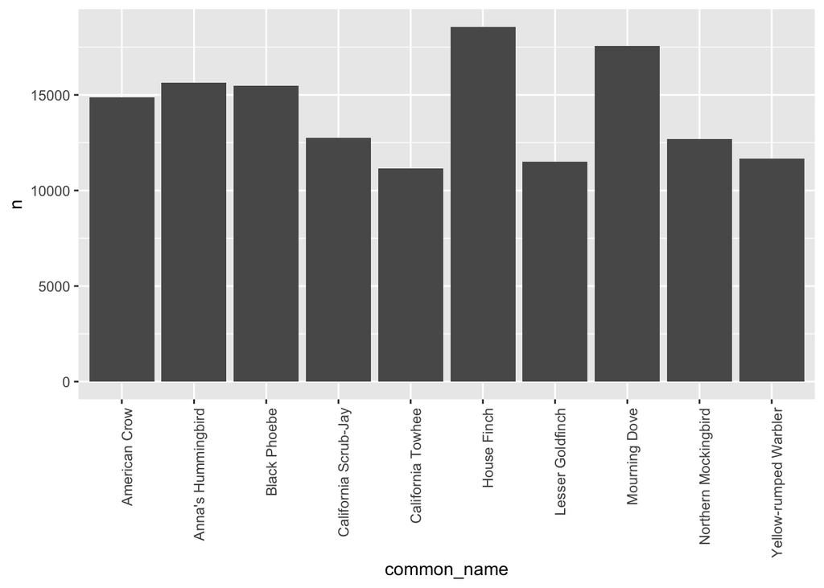

```r
birds %>%
  count(common_name) %>%
  arrange(desc(n)) %>%
  head(n=10) %>%
  ggplot(aes(x = common_name, y = n)) +
    geom_col() + theme(axis.text.x = element_text(angle = 90, hjust = 1))
```

Next let’s put the top ten birds observations on a map. The first step we’ll need to do is filter our data set and retain only the occurances of our top ten birds. Why are we doing this? Mapping all birds with all sighting would likely overwhelm the maps with lots of overplotting, making it hard to read.

Below, we’ll pipe birds into filter and only retain the birds we want. We’ll assign this to a new dataframe called top10birds.

```r
top10birds <- birds %>%
  filter(common_name == c("American Crow", "Anna's Hummingbird", "Black Phoebe", "California Scrub-Jay", "California Towhee", "House Finch", "Lesser Goldfinch", "Mourning Dove", "Northern Mockingbird", "Yellow-rumped Warbler"))
```

Ok, for the mapping, we use a package called `ggmap`. Inside the `ggmap` function we use a function called `get_stamenmap` and that function wants a bounding box `bbox` - this defines what the rectangular area of the world we want to map to appear. `get_stamen` will return the tiles (images) that represent that bounding box. After this we tell `ggmap` the type of plot we want to overlay on the map `geom_point`. Inside of this we set what variables in our dataset contain the latitude and longitude and how we want to color the dots (by `common_name`). We tell `ggmap` what dataframe to use and finally, we set an `alpha` or transparancy to our points. This makes them slightly transparent so we can see more of the underlying structure if they overlay each othter. Ok, that was a lot. Let’s run and look at it.

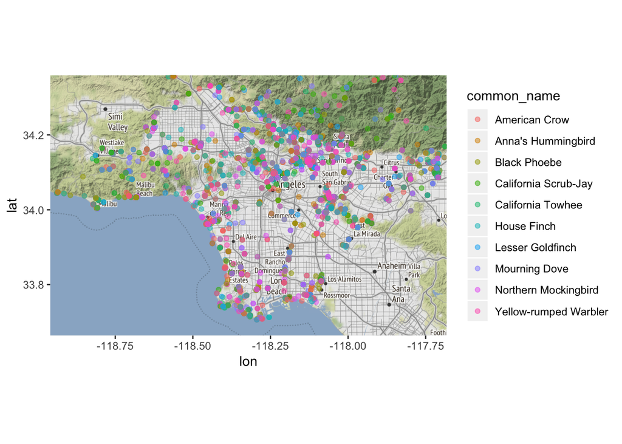

```r
ggmap(get_stamenmap(bbox = c(left = -118.9596, bottom = 33.6633, right =
  -117.6825, top = 34.3588), zoom=10)) +
    geom_point(aes(x = longitude, y = latitude, color=common_name), data = top10birds, alpha = .5)
```